# Ozan_clustering_Project

## Clustering Algorithms - Poland's Suicide Rate Analysis between years (1990 - 2015)

**Name - Surname** = Ozan Can Demir

**Student Number** = 402533

**Department** = Data Science and Business Analytics

**Project** = Clustering

### Objectives

Cluster analysis or clustering is the task of grouping a set of objects in such a way that objects in the same group (called a cluster) are more similar (in some sense) to each other than to those in other groups (clusters).

So, in this project my aim is to analyze the rate of suicide for Poland between years 1990 - 2015 and apply clustering algorithms on the data.

### Packages

```python
!pip install -U scikit-learn
```

[output not shown]

[output not shown]

[output not shown]

```python
import numpy as np
import pandas as pd
import matplotlib.pyplot as plt
import seaborn as sns; sns.set()
import warnings
warnings.filterwarnings(action="ignore")
plt.style.use('ggplot')
%matplotlib inline
```

### Data

The Data which is used in my project was downloaded from the source: https://github.com/RoyMachineLearning/Suicide-Rates-Overview-1985-to-2016 and adjusted by myself for the project purposes.

I did not use any pre-prepared data in my project.

### Details of Data Set

```python
df_Poland = pd.read_csv('C:\\Users\\Ozan\\Downloads\\data_Poland.csv')
```

```python
df_Poland.head()
```

|  | Country | Year | Gender | Age | SuicidesNo | Population | Suicides/100kPop | HDIForYear | GDP_per_Year ($) | GDP_per_Capita ($) | Generation |
| --- | --- | --- | --- | --- | --- | --- | --- | --- | --- | --- | --- |
| 0 | Poland | 1990 | male | 35-54 years | 1670 | 4766000 | 35.04 | 0.713 | 65,977,749,037.00 | 1876 | Silent |
| 1 | Poland | 1990 | male | 55-74 years | 890 | 2665000 | 33.40 | 0.713 | 65,977,749,037.00 | 1876 | G.I. Generation |
| 2 | Poland | 1990 | male | 25-34 years | 917 | 3012400 | 30.44 | 0.713 | 65,977,749,037.00 | 1876 | Boomers |
| 3 | Poland | 1990 | male | 75+ years | 141 | 517200 | 27.26 | 0.713 | 65,977,749,037.00 | 1876 | G.I. Generation |
| 4 | Poland | 1990 | male | 15-24 years | 440 | 2720300 | 16.17 | 0.713 | 65,977,749,037.00 | 1876 | Generation X |

```python
df_Poland.tail()
```

|  | Country | Year | Gender | Age | SuicidesNo | Population | Suicides/100kPop | HDIForYear | GDP_per_Year ($) | GDP_per_Capita ($) | Generation |
| --- | --- | --- | --- | --- | --- | --- | --- | --- | --- | --- | --- |
| 283 | Poland | 2015 | female | 75+ years | 77 | 1790695 | 4.30 | NaN | 477,355,617,456.00 | 13228 | Silent |
| 284 | Poland | 2015 | female | 15-24 years | 61 | 2176442 | 2.80 | NaN | 477,355,617,456.00 | 13228 | Millenials |
| 285 | Poland | 2015 | female | 25-34 years | 71 | 2931931 | 2.42 | NaN | 477,355,617,456.00 | 13228 | Millenials |
| 286 | Poland | 2015 | male | 5-14 years | 12 | 1953588 | 0.61 | NaN | 477,355,617,456.00 | 13228 | Generation Z |
| 287 | Poland | 2015 | female | 5-14 years | 7 | 1855256 | 0.38 | NaN | 477,355,617,456.00 | 13228 | Generation Z |

Random selection in dataset

```python
df_Poland.sample(5)
```

|  | Country | Year | Gender | Age | SuicidesNo | Population | Suicides/100kPop | HDIForYear | GDP_per_Year ($) | GDP_per_Capita ($) | Generation |
| --- | --- | --- | --- | --- | --- | --- | --- | --- | --- | --- | --- |
| 250 | Poland | 2012 | male | 5-14 years | 12 | 1898168 | 0.63 | 0.838 | 500,360,816,828.00 | 13894 | Generation Z |
| 162 | Poland | 2005 | female | 35-54 years | 388 | 5514733 | 7.04 | 0.805 | 306,125,173,853.00 | 8417 | Boomers |
| 43 | Poland | 1993 | female | 75+ years | 61 | 968700 | 6.30 | NaN | 96,045,645,026.00 | 2683 | G.I. Generation |
| 34 | Poland | 1992 | male | 5-14 years | 39 | 3366400 | 1.16 | NaN | 94,337,050,693.00 | 2650 | Millenials |
| 239 | Poland | 2011 | female | 5-14 years | 4 | 1816103 | 0.22 | 0.833 | 528,832,185,770.00 | 14686 | Generation Z |

```python
df_Poland.info()
```

```
<class 'pandas.core.frame.DataFrame'>
RangeIndex: 288 entries, 0 to 287
Data columns (total 11 columns):
 #   Column              Non-Null Count  Dtype
---  ------              --------------  -----
 0   Country             288 non-null    object
 1   Year                288 non-null    int64
 2   Gender              288 non-null    object
 3   Age                 288 non-null    object
 4   SuicidesNo          288 non-null    int64
 5   Population          288 non-null    int64
 6   Suicides/100kPop    288 non-null    float64
 7   HDIForYear          108 non-null    float64
 8   GDP_per_Year ($)    288 non-null    object
 9   GDP_per_Capita ($)  288 non-null    int64
 10  Generation          288 non-null    object
dtypes: float64(2), int64(4), object(5)
memory usage: 24.9+ KB
```

```python
print(df_Poland.columns)
```

```
Index(['Country', 'Year', 'Gender', 'Age', 'SuicidesNo', 'Population',
       'Suicides/100kPop', 'HDIForYear', 'GDP_per_Year ($) ',
       'GDP_per_Capita ($)', 'Generation'],
      dtype='object')
```

#### Columns Details

- *SuicidesNo* = number of suicides
- *Suicides/100kPop* = suicide rate of per 100 000 population
- *HDIForYear* = a statistical tool used to measure a country's overall achievement in its social and economic dimensions
- *GDP_per_Year* = the total monetary or market value of all the finished goods and services produced within a country's borders in a specific time period.
- *GDP_per_Capita* = measure of a country's economic output that accounts for its number of people.
- *Generation* = *Silent Gen*-1925-1945, *Boomers*-1946-1963, *Gen X*-1964-1978, *Gen Y*-1979-1995, *Gen Z*-1995-2010

#### Missing Value Check

```python
df_Poland.isnull().sum()
```

```
Country                 0
Year                    0
Gender                  0
Age                     0
SuicidesNo              0
Population              0
Suicides/100kPop        0
HDIForYear            180
GDP_per_Year ($)        0
GDP_per_Capita ($)      0
Generation              0
dtype: int64
```

We can see that HDI column has some missing values in our data, for analze purposes we will fill them up with mean of the HDI in our data.

```python
df_Poland.fillna(df_Poland['HDIForYear'].mean(), inplace=True)
df_Poland['HDIForYear'].isna().sum()
```

```
0
```

```python
df_Poland.shape
```

```
(288, 11)
```

After this change, we can make sure that our data has no missing value for analyze. This will allow us to make correct interpretations on our data.

#### Descriptive Statistics of Data

```python
df_Poland.describe()
```

|  | Year | SuicidesNo | Population | Suicides/100kPop | HDIForYear | GDP_per_Capita ($) |
| --- | --- | --- | --- | --- | --- | --- |
| count | 288.000000 | 288.000000 | 2.880000e+02 | 288.000000 | 288.000000 | 288.000000 |
| mean | 2002.916667 | 482.979167 | 3.007570e+06 | 15.269514 | 0.803000 | 8146.458333 |
| std | 7.672295 | 619.693815 | 1.352323e+06 | 14.718888 | 0.027534 | 4695.599330 |
| min | 1990.000000 | 3.000000 | 4.575000e+05 | 0.090000 | 0.713000 | 1876.000000 |
| 25% | 1995.750000 | 73.750000 | 2.278675e+06 | 2.717500 | 0.803000 | 4294.000000 |
| 50% | 2003.500000 | 261.000000 | 2.932916e+06 | 7.165000 | 0.803000 | 6498.500000 |
| 75% | 2009.250000 | 653.250000 | 3.562976e+06 | 28.905000 | 0.803500 | 13247.000000 |
| max | 2015.000000 | 2430.000000 | 5.705500e+06 | 45.690000 | 0.843000 | 15119.000000 |

### Part - 1: Exploratory Data Analysis

Visualization with barplot:

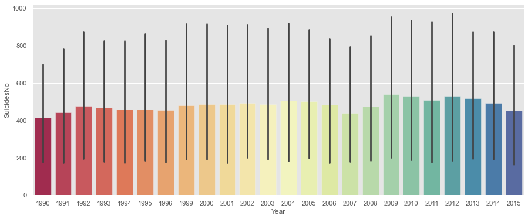

```python
f,ax = plt.subplots(1,1,figsize=(15,6))
ax = sns.barplot(x = df_Poland['Year'], y = 'SuicidesNo',
                data=df_Poland, palette='Spectral')
```

```python
suicide_numbers = df_Poland
suicide_numbers = suicide_numbers.groupby('Year')[['SuicidesNo']].sum().reset_index()
suicide_numbers = suicide_numbers.sort_values(by='Year', ascending=True)
suicide_numbers.style.background_gradient(cmap='Oranges', subset=['SuicidesNo'])
```

|  | Year | SuicidesNo |
| --- | --- | --- |
| 0 | 1990 | 4970 |
| 1 | 1991 | 5316 |
| 2 | 1992 | 5713 |
| 3 | 1993 | 5624 |
| 4 | 1994 | 5519 |
| 5 | 1995 | 5499 |
| 6 | 1996 | 5446 |
| 7 | 1999 | 5779 |
| 8 | 2000 | 5841 |
| 9 | 2001 | 5855 |
| 10 | 2002 | 5925 |
| 11 | 2003 | 5836 |
| 12 | 2004 | 6072 |
| 13 | 2005 | 6045 |
| 14 | 2006 | 5805 |
| 15 | 2007 | 5284 |
| 16 | 2008 | 5682 |
| 17 | 2009 | 6477 |
| 18 | 2010 | 6357 |
| 19 | 2011 | 6113 |
| 20 | 2012 | 6368 |
| 21 | 2013 | 6218 |
| 22 | 2014 | 5934 |
| 23 | 2015 | 5420 |

The Curve visualization for Suicidal Numbers in Poland (from 1990 to 2015):

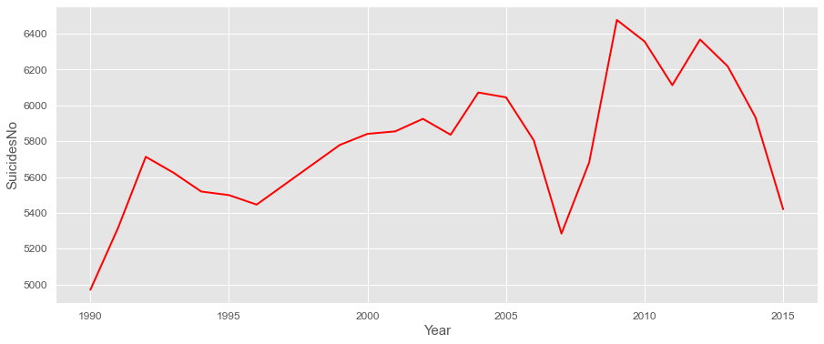

```python
suicidial_curve = df_Poland['SuicidesNo'].groupby(df_Poland.Year).sum()
suicidial_curve.plot(figsize=(15,6), linewidth=2, fontsize=12,color='red')
plt.xlabel('Year', fontsize=15)
plt.ylabel('SuicidesNo',fontsize=15)
```

We can see that suicide rate in 2009 is was reached to the peak point while the lowest rate was observed in 1990.

#### Now, we will analyse how following variables Gender, Age had been observed by years until 2015.

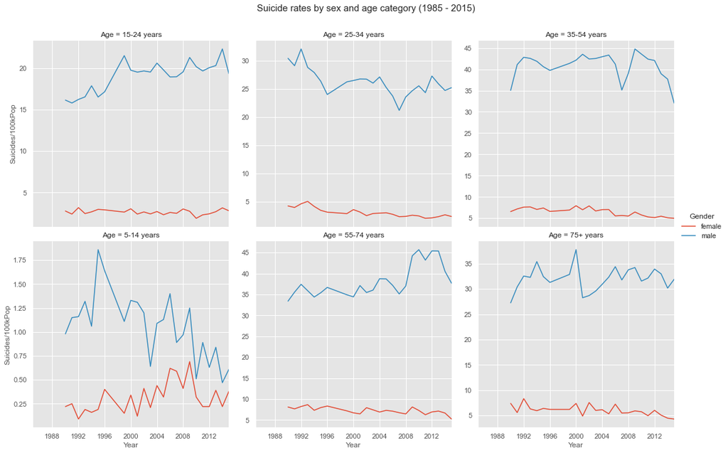

```python
df = df_Poland.groupby(["Year", "Gender", "Age"]).agg("mean").reset_index()

sns.relplot(x = "Year", y = "Suicides/100kPop",
            hue = "Gender", col = "Age", col_wrap = 3, data = df,
            facet_kws=dict(sharey=False), kind = "line")

plt.xlim("1985", "2015")
plt.subplots_adjust(top = 0.9)
plt.suptitle("Suicide rates by sex and age category (1985 - 2015)", size=15);
```

Summary of suicides number by age group

```python
age_grp = df_Poland.groupby('Age')[['SuicidesNo']].sum().reset_index()
age_grp.sort_values(by='SuicidesNo', ascending=False).style.background_gradient(cmap='Greys', subset=['SuicidesNo'])
```

|  | Age | SuicidesNo |
| --- | --- | --- |
| 2 | 35-54 years | 60061 |
| 4 | 55-74 years | 35758 |
| 1 | 25-34 years | 20301 |
| 0 | 15-24 years | 15191 |
| 5 | 75+ years | 6938 |
| 3 | 5-14 years | 849 |

People with age 35-54 and 55-74 committed suicides the most in our data.

**Let's again look at the suicide rate difference between men and women by Age and Gender pairs with barplots.**

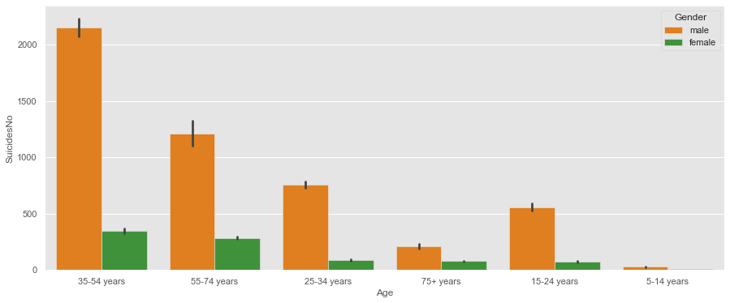

```python
f,ax = plt.subplots(1,1,figsize=(15,6))
ax = sns.barplot(x = df_Poland['Age'], y = 'SuicidesNo',
                  hue='Gender',data=df_Poland, palette='Paired_r')
```

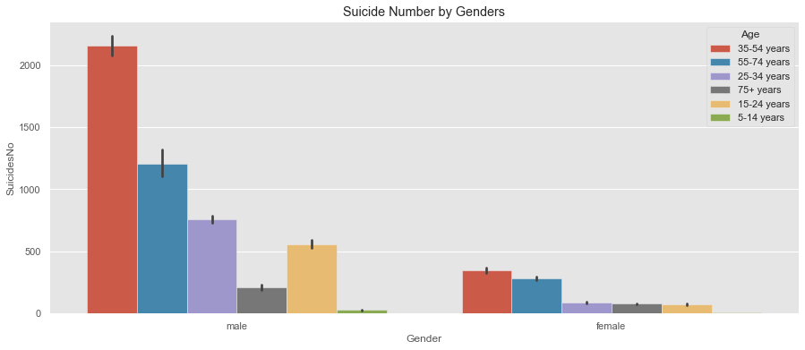

```python
plt.figure(figsize=(15,6))
sns.barplot(df_Poland.Gender,df_Poland.SuicidesNo,hue=df_Poland.Age)
plt.title('Suicide Number by Genders')
plt.show()
```

Suicide rate for ages groups 35-54 is the highest one, and again our data proves that the suicide rate for men is much higher than for women.

The highest number of suicides was in 2009 and the lowest in 1990

**Suicides number by Generation and Gender**

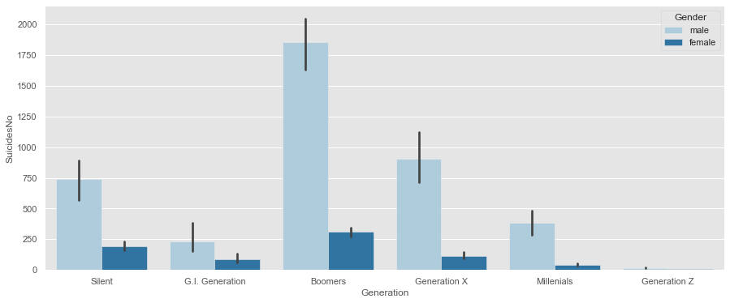

```python
f,ax = plt.subplots(1,1,figsize=(15,6))
ax = sns.barplot(x = df_Poland['Generation'], y = 'SuicidesNo',
                  hue='Gender',data=df_Poland, palette='Paired')
```

These barplots show us that Generation of Boomers has the highest suicide rate in our data, men in general are more likely to commit suicides than women. Generation Z has the lowest suicidal rate with the lowest rate.

**Correlation of Analysis**

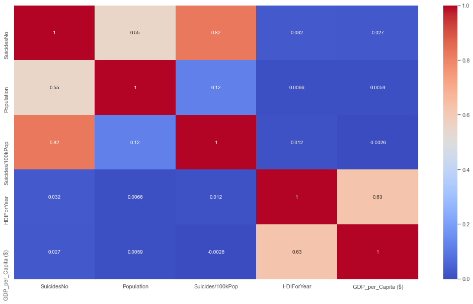

```python
f,ax = plt.subplots(1,1,figsize=(18,10))
ax = sns.heatmap(df_Poland.corr(),annot=True, cmap='coolwarm')
```

#### Let's look at total suicide numbers per year and their relationship.

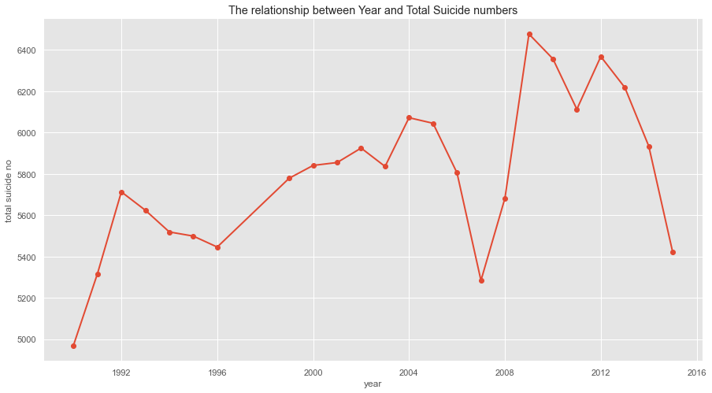

```python
total_suicides = df_Poland.groupby(['Year']).SuicidesNo.sum()
plt.figure(figsize=(15,8))
plt.plot(df_Poland['Year'].unique(),total_suicides,lw=2,marker='o')
plt.xlabel('year')
plt.ylabel('total suicide no')
plt.title('The relationship between Year and Total Suicide numbers')
plt.show()
```

There is no signicificant relationship between year and suicide rates.

#### Now we will look at the relationship between GDP per capita and suicide number, if there is?

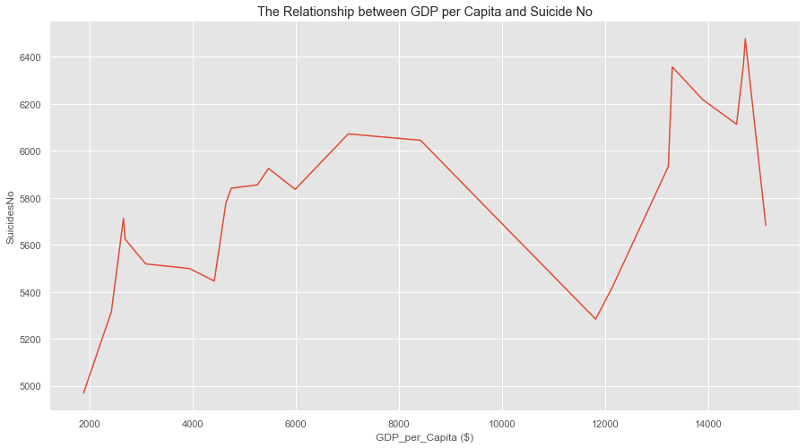

```python
plt.figure(figsize=(15,8))
gdp_suicides = df_Poland.groupby(['GDP_per_Capita ($)']).SuicidesNo.sum() #total suicide numbers for each gdp value.
sns.lineplot(df_Poland['GDP_per_Capita ($)'].unique(),gdp_suicides)
plt.xlabel('GDP_per_Capita ($)')
plt.ylabel('SuicidesNo')
plt.title('The Relationship between GDP per Capita and Suicide No')
plt.show()
```

And also with scatter plot:

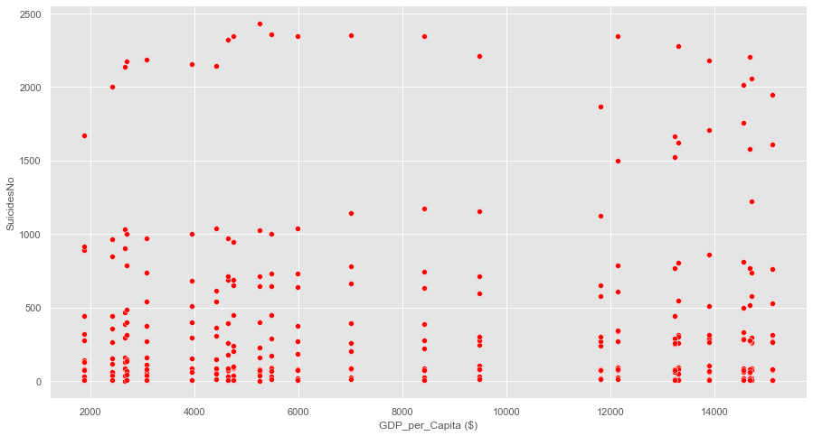

```python
f, ax = plt.subplots(1,1, figsize=(15,8))
ax = sns.scatterplot(x="GDP_per_Capita ($)", y="SuicidesNo", data=df_Poland, color='red')
```

GDP per Capita has no real impact on suicide rate and we are not able to claim that there is significant relation between suicide rate and income. So, we can say that GDP has no effect significantly on suicides.

#### We will check also the relationship between HDI and number of suicides in our data.

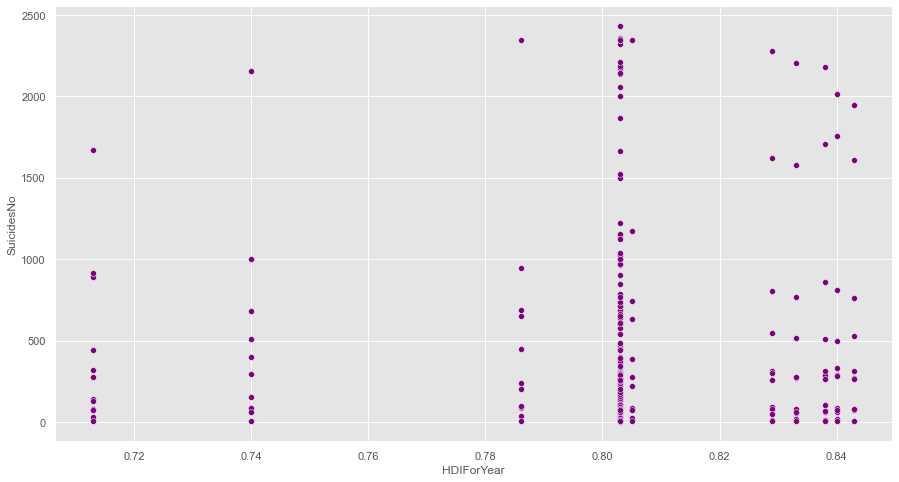

```python
f, ax = plt.subplots(1,1, figsize=(15,8))
ax = sns.scatterplot(x="HDIForYear", y="SuicidesNo", data=df_Poland, color='purple')
```

Again we are not able to claim that there is a significant relations between HDI and number of suicides in our data.

### Part - 2: Clustering Algorithm - K-Means Method

K-means is an iterative clustering algorithm. Starting with randomly chosen K centroids, the algorithm proceeds to update the centroids and their clusters to equilibrium while minimizing the total within cluster variance.

It is primarily used in scenarios with real-valued features because it relies on the Euclidean distance to discover cluster centroids.

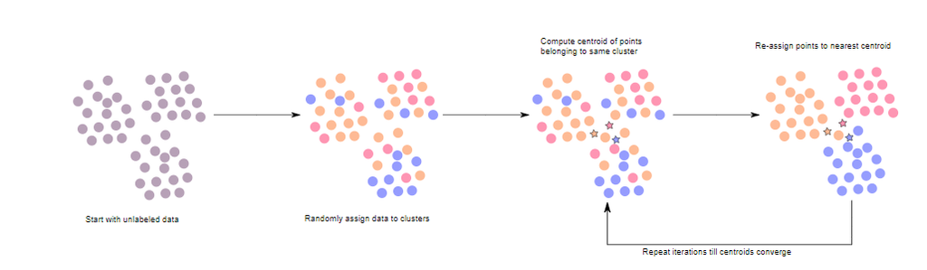

In clustering, the goal of the model is to group the available data into clusters — groups of observations that are similar in some sense.

Turning object types into category and integer types

```python
df_Poland[["Country","Age","Generation","Gender","GDP_per_Year ($) ","Year"]] = \
    df_Poland[["Country","Age","Generation","Gender","GDP_per_Year ($) ","Year"]].astype("category")
df_Poland.info()
```

```
<class 'pandas.core.frame.DataFrame'>
RangeIndex: 288 entries, 0 to 287
Data columns (total 11 columns):
 #   Column              Non-Null Count  Dtype
---  ------              --------------  -----
 0   Country             288 non-null    category
 1   Year                288 non-null    category
 2   Gender              288 non-null    category
 3   Age                 288 non-null    category
 4   SuicidesNo          288 non-null    int64
 5   Population          288 non-null    int64
 6   Suicides/100kPop    288 non-null    float64
 7   HDIForYear          288 non-null    float64
 8   GDP_per_Year ($)    288 non-null    category
 9   GDP_per_Capita ($)  288 non-null    int64
 10  Generation          288 non-null    category
dtypes: category(6), float64(2), int64(3)
memory usage: 15.3 KB
```

Using cat.codes method to convert category into numerical labels

```python
columns = df_Poland.select_dtypes(['category']).columns
df_Poland[columns] = df_Poland[columns].apply(lambda fx: fx.cat.codes)
df_Poland.dtypes
```

```
Country                  int8
Year                     int8
Gender                   int8
Age                      int8
SuicidesNo              int64
Population              int64
Suicides/100kPop      float64
HDIForYear            float64
GDP_per_Year ($)         int8
GDP_per_Capita ($)      int64
Generation               int8
dtype: object
```

```python
df_Poland.columns
```

```
Index(['Country', 'Year', 'Gender', 'Age', 'SuicidesNo', 'Population',
       'Suicides/100kPop', 'HDIForYear', 'GDP_per_Year ($) ',
       'GDP_per_Capita ($)', 'Generation'],
      dtype='object')
```

```python
# Since variable "Country" makes no sense in our data (because all of the data colled in Poland), we drop it as well
x = df_Poland.drop(['SuicidesNo','Country'], axis=True)
y = df_Poland['SuicidesNo']
```

```python
x.columns
```

```
Index(['Year', 'Gender', 'Age', 'Population', 'Suicides/100kPop', 'HDIForYear',
       'GDP_per_Year ($) ', 'GDP_per_Capita ($)', 'Generation'],
      dtype='object')
```

#### Labels

```python
y.to_frame()
```

|  | SuicidesNo |
| --- | --- |
| 0 | 1670 |
| 1 | 890 |
| 2 | 917 |
| 3 | 141 |
| 4 | 440 |
| ... | ... |
| 283 | 77 |
| 284 | 61 |
| 285 | 71 |
| 286 | 12 |
| 287 | 7 |

288 rows × 1 columns

#### K-means Clustering

Our task now is to cluster the **Data** into two groups

1- the ones with high number of suicides and, \ 2- the ones with low number of suicides.

For that we have to drop the 'suicides_no' column from the dataset and make it unlabeled

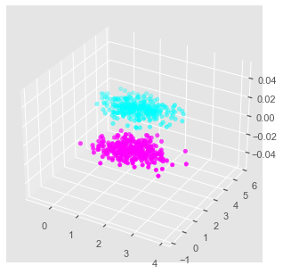

```python
!pip install sklearn
from sklearn.datasets.samples_generator import make_blobs
from mpl_toolkits.mplot3d import Axes3D
x = df_Poland.drop(['SuicidesNo','Country'], axis=True)
y = df_Poland['SuicidesNo']
kmeans = KMeans(n_clusters=2)
kmeans.fit(x)
KMeans(algorithm='auto', copy_x=True, init='k-means++', max_iter=600,
    n_clusters=2, n_init=10, n_jobs=1, precompute_distances='auto',
    random_state=0, tol=0.0001, verbose=0)
y_kmeans = kmeans.predict(x)
x, y_kmeans = make_blobs(n_samples=600, centers=2, cluster_std=0.60, random_state=0)
fig = plt.figure()
ax = Axes3D(fig)
ax.scatter(x[:,0], x[:,1], c=y_kmeans, cmap='cool')
```

#### Silhouette Score

Uses a distance metric to measure how similar a point is to its own cluster and how dissimilar the point is from points in other clusters. Ranges between -1 and 1 and positive values closer to 1 indicate that the clustering is good.

```python
from sklearn.metrics import silhouette_score
print(silhouette_score(x, y_kmeans))
```

```
0.7107290505066528
```

#### RESULT

In my project, at first I started by processing the data (Suicide rate for Poland between 1990 - 2015). Since it is very important to visualize data, I have tried to visualize it with packages provided in Pyhton. Thanks to visualization, we ar eable to understand data in a meaning way, detect relative patterns, trends in data and existing outliers.

As a Clustering Algorithm, I used K-Means clustering method. Because K-Means clustering method was the most suitable one for my data and for my algorithm perspective. The data gives us the number of suicides with given period of 1990 - 2015 with some domain knowledge in Poland. We can identify that Age and Gender have significant effects on the results, however GDP and HDI have no effects on human being for committing a suicide.

The data does not contain larger number of observations and in addition different variables. Data with more developed and deeper obervations, would give us more descriptive results accordingly.

To sum up, clustering is really wide-range topic in Machine Learning to search and get confident. From Big Data perspective, it has ability of handle with continous streaming data and grouping them efficiently.

#### REFERENCES

https://the-learning-machine.com/article/ml/k-means?gclid=CjwKCAiAm-2BBhANEiwAe7eyFHl8x88LIt1XS2XYxBvx_31WYVCY0ArUsauKZrEss7RLK8sOM5MJcxoCkEMQAvD_BwE

https://pl.wikipedia.org/wiki/Wikipedia

https://github.com/search?q=kmeans

https://github.com/search?q=clustering

https://www.oreilly.com/library/view/hands-on-machine-learning/9781492032632/